## Ex-04.3 homework

Paul Johnson, CRMDA <pauljohn@ku.edu>

Apr. 3 2018

Abstract

RHS grader1 exercise

# Load libraries

```r
library(foreign)
library(lme4)
```

# Data import

```r
fn <- "gcse"
if (!file.exists(paste0(fn, ".dta12"))) {
    download.file(paste0("http://www.stata-press.com/data/mlmus3/", fn, ".dta"),
                  destfile = paste0(fn, ".dta12"))
}
```

```r
homework <- read.dta("homework.dta12")
```

```r
rockchalk::summarize(homework)
```

```
## Numeric variables
##              schid      stuid      ses      meanses    homework     white
## min         6053          0         -2.41      -1.07       0          0
## med        25642         51         -0.12      -0.20       1          1
## max        72991         99          1.85       1.18       7          1
## mean       35488.71      49.86       0          0          1.97       0.75
## sd         26056.71      28.62       0.88       0.62       1.48       0.43
## skewness       0.19      -0.02      -0.01       0.52       1.03      -1.16
## kurtosis      -1.64      -1.21      -0.69      -0.80       0.33      -0.66
## nobs         519        519        519        519        519        519
## nmissing       0          0          0          0          0          0
##            parented    public      ratio    percmin      math       sex
## min            1          0         10          0         30          1
## med            3          1         18          2         51          2
## max            6          1         28          7         71          2
## mean           3.29       0.61      16.76       2.50      51.72       1.52
## sd             1.44       0.49       4.93       2.04      10.71       0.50
## skewness       0.34      -0.45       0.33       0.78       0.06      -0.08
## kurtosis      -0.73      -1.80      -0.62      -0.28      -1.16      -2
## nobs         519        519        519        519        519        519
## nmissing       0          0          0          0          0          0
##              race      sctype      cstr      scsize      urban     region
## min            1          1          2          1          1          1
## med            4          1          4          3          2          2
## max            5          4          5          7          3          3
## mean           3.61       1.98       3.82       3.23       1.83       2.13
## sd             0.80       1.33       0.79       1.40       0.86       0.70
## skewness      -1.92       0.76      -0.21       0.98       0.33      -0.18
## kurtosis       2.89      -1.30      -0.46       0.24      -1.57      -0.99
## nobs         519        519        519        519        519        519
## nmissing       0          0          0          0          0          0
```

# 4.3.1: write out the model

$$math_{ji} = (\beta_0 + \beta_{0j}) + (\beta_{1} + b_{1j}) homework_{ji} + \beta_{2} white_{ji} + \beta_{3} ratio_{j} + \epsilon_{ji}$$

or

$$math_{ji} = \beta_0 + \beta_{1} homework_ji + \beta_{2} white_ji + \beta_{3} ratio_{j} + \beta_{0j} + b_{1j} homework_{ji} + \epsilon_{ji}$$

Would I want to re-name all the variables as $y_{ji}$ and $x1_{ji}$ or similar?

The model assumes that

### The random effects are correlated, bivariate normal.

$$(b_{0j}, b_{1j}) \sim MVN(0, \Sigma_{b})$$

### $\epsilon_{ji}$ is normal.

he expected value of epsilon is 0:

$$\epsilon_{ji} \sim N(0, \Sigma_{\epsilon})$$

It is actually a stronger assumption, if the $b_{0j}$ and $b_{1j}$ were know first, then

$$\epsilon_{ji} b_{0j},b_{1j} = \sim N(0, \Sigma_{\epsilon})$$

I am consciously refusing to spawn new symbols for variance matrices. For me, all variance matrices are $\Sigma$

# 04.3 2

```r
m1 <- lmer(math ~ homework + white + ratio + (homework | schid),
           data = homework, REML = FALSE)
summary(m1)
```

```
## Linear mixed model fit by maximum likelihood  ['lmerMod']
## Formula: math ~ homework + white + ratio + (homework | schid)
##    Data: homework
##
##      AIC      BIC   logLik deviance df.resid
##   3643.3   3677.3  -1813.6   3627.3      511
##
## Scaled residuals:
##      Min       1Q   Median       3Q      Max
## -2.30879 -0.67145 -0.01695  0.67851  3.07147
##
## Random effects:
##  Groups   Name        Variance Std.Dev. Corr
##  schid    (Intercept) 55.07    7.421
##           homework    16.35    4.043    -0.86
##  Residual             52.58    7.251
## Number of obs: 519, groups:  schid, 23
##
## Fixed effects:
##             Estimate Std. Error t value
## (Intercept)  46.4417     3.6268  12.805
## homework      1.9091     0.8947   2.134
## white         3.3948     0.9752   3.481
## ratio        -0.1441     0.1847  -0.780
##
## Correlation of Fixed Effects:
##          (Intr) homwrk white
## homework -0.388
## white    -0.125 -0.028
## ratio    -0.869  0.004 -0.070
```

### Compare that to the stata output

I’ll put in an image of stata output

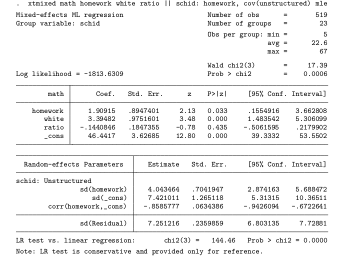

That’s the Stata answer

### Inspect the estimated random effects:

```r
ranef(m1)
```

```
## $schid
##       (Intercept)   homework
## 6053     4.444572  0.2459334
## 6327    14.431854 -7.8910270
## 6467    -4.992315  4.1617628
## 7194     5.572551 -4.2273383
## 7472     3.328190 -4.7981761
## 7474    10.049871 -4.4679169
## 7801     8.250269 -4.6166394
## 7829     4.964013 -4.5710883
## 7930    -7.634343  5.3791773
## 24371   -5.852372  2.4103877
## 24725  -11.223168  3.3792816
## 25456    4.734350 -4.8128411
## 25642    3.293536 -3.2821146
## 26537   -1.555141  1.7770108
## 46417    1.744639  2.2565646
## 47583   -3.407835  1.2390344
## 54344   -7.697140  1.3330732
## 62821    9.674103 -0.5071103
## 68448   -7.669965  3.7096721
## 68493   -5.548263  3.1658494
## 72080   -1.849317  2.3536760
## 72292   -8.709926  4.0823611
## 72991   -4.348164  3.6804675
```

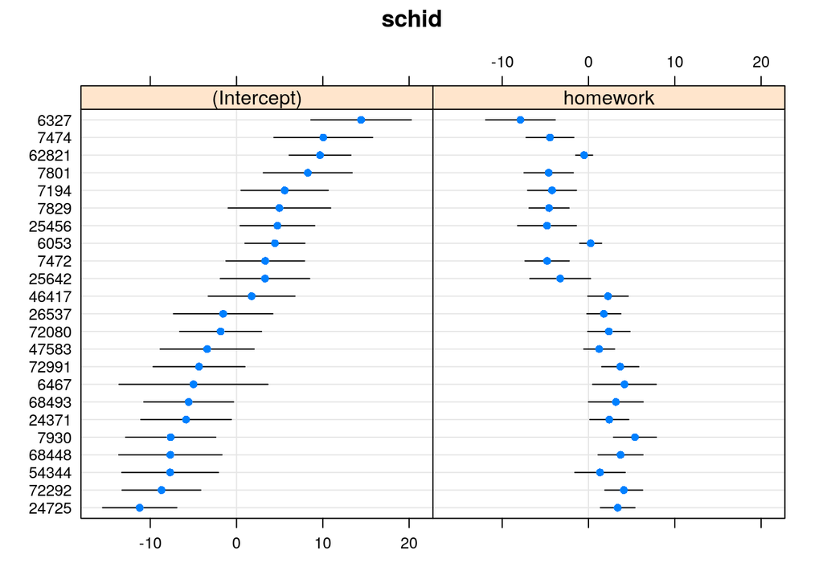

```r
m1.vc <- ranef(m1, condVar = TRUE)
library(lattice)
dotplot(m1.vc)
```

### Compare those to the estimated sigma! ?

```r
m1.vc.intercept <- m1.vc[["schid"]][ , "(Intercept)"]
sd(m1.vc.intercept)
```

```
## [1] 7.065471
```

```r
m1.vc.homework <- m1.vc[["schid"]][ , "homework"]
sd(m1.vc.homework)
```

```
## [1] 3.897366
```

```r
VarCorr(m1)
```

```
##  Groups   Name        Std.Dev. Corr
##  schid    (Intercept) 7.4210
##           homework    4.0435   -0.859
##  Residual             7.2512
```

I want the variance-covariance matrix. Reading `?VarCorr` I try this

```r
m1.varcorr <- VarCorr(m1)
print(m1.varcorr, comp = c("Variance"))
```

```
##  Groups   Name        Variance Corr
##  schid    (Intercept) 55.071
##           homework    16.350   -0.859
##  Residual             52.580
```

Then

```r
as.data.frame(m1.varcorr)
```

```
##        grp        var1     var2      vcov      sdcor
## 1    schid (Intercept)     <NA>  55.07136  7.4210078
## 2    schid    homework     <NA>  16.34959  4.0434620
## 3    schid (Intercept) homework -25.76297 -0.8585777
## 4 Residual        <NA>     <NA>  52.58014  7.2512162
```

### Visualize

What do you want?

Could also have lattice plot

### 4.3 3 variance of math conditional on covariates

$$\widehat{Var(math_{ji})}=Var(\beta_0 + \beta_{1} homework_ji + \beta_{2} white_ji + \beta_{3} ratio_ji + b_{0j} + b_{1j} homework_{ji} + \epsilon_{ji})$$

$$\widehat{Var(math_{ji})}=Var(b_{0j} + b_{1j} homework_{ji} + \epsilon_{ji})$$

We throw out everything that does not have random variance at the $j$ level or the error term.

### Math reminder

The general rule for constants $k_1$ and $k_2$ and random variables $Z1$ and $Z2$

$$Var(k_1 Z1 + k_2 Z2) = k_{1}^{2} Var(Z1) + k_{2} Var(Z2) + 2 k_1 k_2 Cov(Z1,Z2)$$

## Application

In our context, That’s how we calculate $Var(b_{0j} + b_{1_j} homework_{ji})$

- Z1 = random effect for intercept, $b_{0j}$
- Z2 = random effect for slope, $b_{1j}$
- Var(b_0) is estimated in the output: 55.07
- Var(b_1) is estimated as: 16.349
- Cov(b0, b1) is estimated as: -25.76
- $k_1$ = 1
- $k_2$ = homework_{ji}

### Write out the variance of the parts with random effects

$$Var(b_{0j} + homework_{ji} b_{1j}) =
Var(b_{0j}) + homework_{ji}^2 Var(b_{1j}) + 2 homework_{ji} Cov(b_{0j}, b_{1j})$$

### Oops, epsilon is needed too

# 4.3 4

Level 1 model:

$$math_{ji} = \beta_0^* + \beta_1^* homework_{ji} + \beta_2^*white_{ji} + \epsilon_{ji}$$

and at level 2 we have 2 models,

$$beta_0^* = \beta_1 + \beta_4 ratio_j + \beta_5 sesmean_j + b_{0j}$$

$$\beta_1^* = \beta_3 + \beta_6 sesmean_j + b_{1j}$$

$$math_{ji} = (put in \beta_0^*) +
(put in \beta_1^*) homework_{ji} + \beta_2^*white_{ji} + \epsilon_{ji}$$

And what do you get?

# Fit that

## Use lmer

```r
m2 <- lmer(math ~ homework + white + ratio + meanses*homework + (homework | schid),
           data = homework, REML = FALSE)
summary(m2)
```

```
## Linear mixed model fit by maximum likelihood  ['lmerMod']
## Formula:
## math ~ homework + white + ratio + meanses * homework + (homework |
##     schid)
##    Data: homework
##
##      AIC      BIC   logLik deviance df.resid
##   3636.7   3679.2  -1808.3   3616.7      509
##
## Scaled residuals:
##      Min       1Q   Median       3Q      Max
## -2.28801 -0.68992 -0.02178  0.68120  3.00530
##
## Random effects:
##  Groups   Name        Variance Std.Dev. Corr
##  schid    (Intercept) 49.92    7.065
##           homework    15.30    3.911    -0.92
##  Residual             52.73    7.261
## Number of obs: 519, groups:  schid, 23
##
## Fixed effects:
##                  Estimate Std. Error t value
## (Intercept)      44.32015    3.09277  14.330
## homework          1.99003    0.88020   2.261
## white             3.14125    0.95662   3.284
## ratio             0.01606    0.15421   0.104
## meanses           4.02376    2.89094   1.392
## homework:meanses  0.57528    1.55904   0.369
##
## Correlation of Fixed Effects:
##             (Intr) homwrk white  ratio  meanss
## homework    -0.474
## white       -0.113 -0.025
## ratio       -0.823  0.010 -0.129
## meanses      0.028 -0.153 -0.081  0.101
## homwrk:mnss -0.123  0.169  0.006  0.046 -0.886
```

## Compare to stata

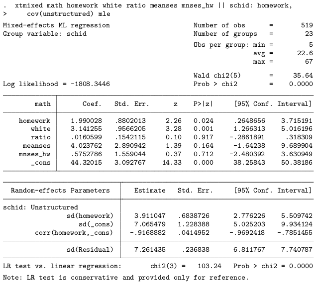

That’s the Stata answer